# Lab2 Week 03: [Netlogo Exercise]

Author

McKenna Taylor (747408407)

Published

August 7, 2026

## How to include screenshots and images (jpg or png)

Your NetLogo results are reported as screenshots, so you will embed external image files in this document.

1. Take a screenshot of the NetLogo world or interface (on macOS press Cmd+Shift+4, on Windows use Snipping Tool).
2. Save it as a `.png` or `.jpg` file inside an `images/` folder next to this `.qmd` file, with a descriptive name such as `images/fire-density60.png`.
3. Embed it with Markdown image syntax, and add a caption and a width:

```markdown
![Final state of the world at density 60](images/fire-density60.png){width=70%}
```

Because `embed-resources: true` is set in the YAML header, the images are bundled into the rendered HTML file. Remember to commit and push the `images/` folder along with the `.qmd`, otherwise the images will be missing when the file is rendered elsewhere.

## Part A: Build the Model

Percent burned is 94.1. Rip forest.

Paste your NetLogo code here:

```
globals [
  initial-trees
  burned-trees
]

to setup
  clear-all
  ask patches [
    if random 100 < density [ set pcolor green ]
  ]
  ask patches with [ pxcor = min-pxcor ] [
    if pcolor = green [ set pcolor red ]
  ]
  set initial-trees count patches with [ pcolor = green or pcolor = red ]
  set burned-trees 0
  reset-ticks
end

to go
  if not any? patches with [ pcolor = red ] [ stop ]
  ask patches with [ pcolor = red ] [
    ask neighbors4 with [ pcolor = green ] [
      set pcolor red
    ]
    set pcolor grey
    set burned-trees burned-trees + 1
  ]
  tick
end
```

Embed your screenshot of the world after a run:

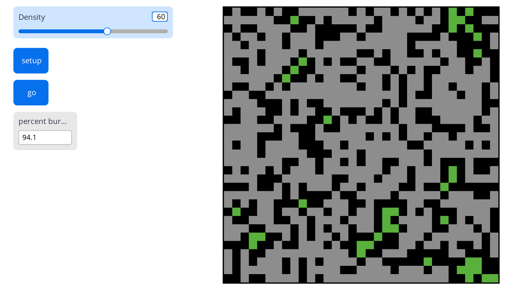

Build the model